# Nextreme

Dr.-Ing. Bora Shehu, modifiziert durch Dimitri Falk

2026-02-25

# Einführung

In diesem Beispiel werden praktische Anwendungsfälle in R gezeigt, wie das Nextreme-Package, welches die Inhalte des Arbeitsblattes DWA-A 531 umsetzt, verwendet werden kann. Beispielhaft werden die 5-Minuten-Niederschlagssummen der Wetterstation Görlitz verwendet, die frei über das Climate Data Center (CDC) des Deutschen Wetterdienstes (DWD) verfügbar sind.

Ein Überblick über die Ziele und einzelnen Schritte ist nachfolgend aufgeführt:

1. **Datenerfassung**: Format der 5-Minuten-Niederschlagszeitreihe
2. **Datenaufbereitung**: Bildung von jährlichen Serien für definierte Dauerstufen
3. **Extremwertstatistiche Auswertung**: Schätzung von Parametern und Wiederkehrzeiten
4. **Vergleiche zwischen lokaler Extremwertstatistik und KOSTRA-DWD-2020**

# Benötigte Software

Zunächst ist es erforderlich, [R](https://www.r-project.org) zu installieren. Es wird zudem dringend empfohlen, auch [R Studio](https://www.rstudio.com) zu installieren. Hierbei handelt es sich um eine Entwicklungsumgebung (IDE), die das Arbeiten mit R wesentlich erleichtert. Eine Anleitung zur Installation beider Programme steht [hier](https://cran.r-project.org/doc/manuals/r-devel/R-admin.html) (für alle gängigen Betriebssysteme) zur Verfügung.

Nach der Installation der beiden Programme ist ein neues R-Skript zu erstellen (File > New File > R Script). In diesem Dokument kann nun Zeile für Zeile der hier vorgestellte Code hinzugefügt und ausgeführt werden, um die Ergebnisse der lokalen Extremwertanalyse, die für die Station Görlitz durchgeführt wurde, zu reproduzieren.

Zunächst ist es erforderlich, das für das Arbeitsblatt DWA-A 531 entwickelte R-Package “Nextreme” zu installieren und einzubinden.

1. Das Paket kann aus der bereitgestellten Archiv-Datei (Nextreme.zip) mit folgenden Schritten installiert werden: Tools > Install Packages > Install from: Package Archive File (.zip; .tar.gz) > Browse to the package location > Install.
2. Das Package kann aber auch in seiner aktuellsten (Entwicklungs-)Version direkt von GitHub installiert werden:

```r
# install.packages("pak")
pak::pak("dimfalk/Nextreme")
```

Die von “Nextreme” verwendeten Dritt-Packages sollten aufgrund von definierten Abhängigkeiten mit der Installation des Packages automatisch verfügbar sein. Sollte dem nicht so sein, können diese wie folgt manuell nachinstalliert werden:

```r
install.packages("evd")
install.packages("lmomco")
install.packages("lubridate")
install.packages("terra")
```

Um “Nextreme” zu laden, verwenden Sie den folgenden Befehl:

```r
library("Nextreme")
```

# Anwendungsbeispiele

## 1. Datenerfassung: Format der 5-Minuten-Niederschlagszeitreihe

Die hier beschriebenen Beispiele basieren auf der 5-Minuten-Niederschlagszeitreihe der Station Görlitz, welche vom Deutschen Wetterdienst betrieben wird. Diese Zeitreihe ist bereits im Package *Nextreme* enthalten und kann wie folgt geladen bzw. inspiziert werden:

```r
data("Regendaten_01684")

# Zeige die ersten und letzten Zeilen des Datensatzes
head(Regendaten_01684)
```

```
#>                 Datum RH
#> 1 1991-01-01 00:00:00 NA
#> 2 1991-01-01 00:05:00 NA
#> 3 1991-01-01 00:10:00 NA
#> 4 1991-01-01 00:15:00 NA
#> 5 1991-01-01 00:20:00 NA
#> 6 1991-01-01 00:25:00 NA
```

```r
tail(Regendaten_01684)
```

```
#>                       Datum RH
#> 3155899 2020-12-31 23:30:00  0
#> 3155900 2020-12-31 23:35:00  0
#> 3155901 2020-12-31 23:40:00  0
#> 3155902 2020-12-31 23:45:00  0
#> 3155903 2020-12-31 23:50:00  0
#> 3155904 2020-12-31 23:55:00  0
```

Im Falle der Einbindung von eigenen Niederschlagsdaten ist zu beachten, dass die 5-Minuten-Zeitreihe als *data.frame*-Objekt mit den beiden nachfolgenden Spalten vorliegen muss:

- *Datum*: Zeitstempel als *POSIXct* oder *POSIXlt*,
- *RH*: gemessene Niederschlagshöhe [mm].

Es ist darauf zu achten, dass die Zeitreihe kontinuierlich und lückenfrei ist. Etwaige Fehlwerte sind mit Zeitstempel explizit als *NA* zu kennzeichnen. Vor der Verwendung der Zeitreihe ist zudem sicherzustellen, dass die Niederschlagshöhen keine negativen Werte enthalten und sich in einem plausiblen Wertebereich befinden.

```r
# Überprüfung der Struktur der 5-Minuten-Niederschlagszeitreihe
str(Regendaten_01684)
```

```
#> 'data.frame':    3155904 obs. of  2 variables:
#>  $ Datum: POSIXct, format: "1991-01-01 00:00:00" "1991-01-01 00:05:00" "1991-01-01 00:10:00" "1991-01-01 00:15:00" ...
#>  $ RH   : num  NA NA NA NA NA NA NA NA NA NA ...
```

```r
# Überprüfung, ob die Zeitstempel in der Spalte `Datum` kontinuierlich sind
unique(diff(Regendaten_01684$Datum))
```

```
#> Time difference of 5 mins
```

```r
# Überprüfung des Wertebereichs in Spalte `RH`
range(Regendaten_01684$RH, na.rm = TRUE)
```

```
#> [1]  0.000 15.938
```

## 2. Datenaufbereitung: Bildung von jährlichen Serien für definierte Dauerstufen

Für die 5-Minuten-Niederschlagsreihen der Station Görlitz werden für jede Dauerstufe jährliche Maxima bestimmt und somit eine jährliche Serie gebildet. Dies erfolgt hier nach den im Arbeitsblatt DWA-A 531 beschriebenen Schritten, die sich nachfolgend beschrieben finden:

### 2.1 Ermittlung von Regenhöhen bestimmter Dauerstufen aus den Grunddaten

Ziel ist die Berechnung der jährlichen Maxima für jede der betrachteten Dauerstufen. Zu diesem Zweck kann die Funktion *jaehrliche_maxSerie()* verwendet werden. Hier wird ein Zeitraum von 4 Stunden (*DSDmin*) verwendet, um unabhängige Niederschlagsereignisse voneinander zu trennen. Da die Niederschlagsdaten in Form von 5-Minuten-Summen vorliegen, wird das Intervallargument (*Intervall*) auf 5 gesetzt. Um die Parameter der Extremwertverteilung zu ermitteln, sind die maximalen jährlichen Niederschlagsintensitäten pro Dauerstufe erforderlich. Aus diesem Grund geben wir *SerieTyp = “INT”* an, um die maximalen Intensitäten als Ausgabe zu erhalten.

```r
dur <- c(5, 10, 15, 20, 30, 45, 60, 90, 120, 180, 240, 360, 540, 720, 1080, 1440, 2880, 4320, 5760, 7200, 8640, 10080)

Goerlitz_maxIntSerie <- jaehrliche_maxSerie(Regendaten_01684,
                                            Dauern = dur,
                                            DSDmin = 240,
                                            Intervall = 5,
                                            SerieTyp = "INT")
head(Goerlitz_maxIntSerie)
```

```
#>           5     10     15     20     30     45     60     90    120    180    240   360   540   720  1080  1440  2880  4320  5760
#> 1991 59.304 46.644 38.524 29.883 21.626 16.745 12.601  8.416  6.326  4.917  3.919 3.695 2.981 2.576 2.071 1.823 0.914 0.622 0.502
#> 1992 37.464 37.170 27.596 22.725 16.270 12.181 10.300  9.225  9.343  8.508  7.645 5.463 3.648 2.745 1.837 1.401 0.815 0.561 0.422
#> 1993 56.400 40.800 45.600 39.600 28.200 26.133 21.900 15.467 11.850  7.967  7.148 6.169 4.675 4.512 4.187 3.618 1.890 1.300 0.985
#> 1994 76.800 52.200 40.000 30.900 23.148 20.091 18.258 16.030 17.061 13.770 11.077 8.084 5.578 4.192 2.795 2.104 1.096 0.736 0.557
#> 1995 82.800 81.600 62.800 51.900 36.200 26.000 19.600 13.200  9.900  7.268  6.788 5.438 4.574 3.793 3.122 2.383 1.240 0.865 0.768
#> 1996 74.400 42.600 30.800 24.000 16.400 12.667 10.400  9.067  7.700  6.000  5.175 4.083 3.056 2.767 2.372 2.404 1.219 0.812 0.914
#>       7200  8640 10080
#> 1991 0.422 0.351 0.301
#> 1992 0.340 0.290 0.270
#> 1993 0.853 0.953 0.829
#> 1994 0.479 0.399 0.349
#> 1995 0.768 0.648 0.561
#> 1996 0.766 0.639 0.571
```

Beim erzeugten Objekt *Goerlitz_maxIntSerie* handelt es sich um einen Data Frame mit der maximalen Intensität (mm/h), die in verschiedenen Dauerstufen und Jahren ermittelt wurde.

### 2.2 Berücksichtigung der Intervalllänge

```r
Goerlitz_maxIntSerie_korr1 <- Intervall_Korrektur(Goerlitz_maxIntSerie, Intervall = 5)

head(Goerlitz_maxIntSerie_korr1)
```

```
#>             5       10       15       20     30     45     60     90    120    180    240   360   540   720  1080  1440  2880
#> 1991 67.60656 49.90908 40.06496 30.77949 21.626 16.745 12.601  8.416  6.326  4.917  3.919 3.695 2.981 2.576 2.071 1.823 0.914
#> 1992 42.70896 39.77190 28.69984 23.40675 16.270 12.181 10.300  9.225  9.343  8.508  7.645 5.463 3.648 2.745 1.837 1.401 0.815
#> 1993 64.29600 43.65600 47.42400 40.78800 28.200 26.133 21.900 15.467 11.850  7.967  7.148 6.169 4.675 4.512 4.187 3.618 1.890
#> 1994 87.55200 55.85400 41.60000 31.82700 23.148 20.091 18.258 16.030 17.061 13.770 11.077 8.084 5.578 4.192 2.795 2.104 1.096
#> 1995 94.39200 87.31200 65.31200 53.45700 36.200 26.000 19.600 13.200  9.900  7.268  6.788 5.438 4.574 3.793 3.122 2.383 1.240
#> 1996 84.81600 45.58200 32.03200 24.72000 16.400 12.667 10.400  9.067  7.700  6.000  5.175 4.083 3.056 2.767 2.372 2.404 1.219
#>       4320  5760  7200  8640 10080
#> 1991 0.622 0.502 0.422 0.351 0.301
#> 1992 0.561 0.422 0.340 0.290 0.270
#> 1993 1.300 0.985 0.853 0.953 0.829
#> 1994 0.736 0.557 0.479 0.399 0.349
#> 1995 0.865 0.768 0.768 0.648 0.561
#> 1996 0.812 0.914 0.766 0.639 0.571
```

```r
# mittlere relative Abweichung entspricht dem verwendeten Korrekturfaktor
all.equal(Goerlitz_maxIntSerie, Goerlitz_maxIntSerie_korr1)
```

```
#> [1] "Component \"5\": Mean relative difference: 0.14"  "Component \"10\": Mean relative difference: 0.07"
#> [3] "Component \"15\": Mean relative difference: 0.04" "Component \"20\": Mean relative difference: 0.03"
```

### 2.3 Stationarität und Sprungkorrektur bei kurzen Dauerstufen

Da sich der Sensortyp an der Station Görlitz über die Zeit ändert, wird überprueft, ob die jährliche Serie der kurzen Dauerstufen (5, 10, 15 und 30 Minuten) eine sprunghafte Instationarität aufweisen, die dem Datum des Sensorwechsels entspricht. Wenn es eine solche sprunghafte Instationarität gibt, wird der Sprung eliminiert.

**HINWEIS:** Dieser Schritt wird an der Stelle lediglich durchgeführt, um ein Anwendungsbeispiel zu zeigen. Laut Arbeitsblatt DWA-A 531 sollte eine Sprungkorrektur getestet werden, wenn es einen Sensorwechsel von analog zu digital gab. An der Station Görlitz sind in diesem Beispiel alle Sensoren digital, sodass eine Sprungprüfung und -korrektur eigentlich nicht erforderlich wäre. Hier wird dieser Schritt bloß gezeigt, um einen vollständigen Arbeitsablauf darzulegen.

Zu diesem Zweck kann die Funktion *Sprung_Korrektur()* verwendet werden. Zusätzlich zur Eingabe der jährlichen Serie (*Goerlitz_maxIntSerie*) benötigt die Funktion das Datum des Sensorwechsels in Form eines *Date()*-Objektes als weiteres Argument.

```r
Goerlitz_maxIntSerie_korr2 <- Sprung_Korrektur(Goerlitz_maxIntSerie_korr1, wechselDatum = as.Date("1991-01-01"))

# Differenz vor und nach Anwendung der Funktion `Sprung_Korrektur()` überprüfen.
all.equal(Goerlitz_maxIntSerie_korr1, Goerlitz_maxIntSerie_korr2)
```

```
#> [1] TRUE
```

Da in dem gewählten Beispiel kein Sprung in der Zeitreihe vorliegt, entspricht die Eingabe auch dem von der Funktion *Sprung_Korrektur()* zurückgegebenem Ergebnis.

## 3. Extremwertstatistische Auswertung

Nachfolgend werden Beispiele für die Extremwertanalyse an der Station Görlitz gezeigt.

### 3.1 Schätzung der Parameter zur Beschreibung der Extremwertverteilung über alle Dauerstufen

Ziel ist die Anpassung der generalisierten Extremwertverteilung (GEV) an die jährlichen Serien der Niederschlagsintensität. Die Koutsoyiannis-Methode, wie im Arbeitsblatt DWA-A 531 beschrieben, wird zur Normalisierung der Intensitäten über alle Dauerstufen verwendet.

Zu diesem Zweck kann die Funktion *Parameter_Schaetzung()* verwendet werden, um die Parameter der Extremwertverteilung auf Basis der jährlichen Serien zu schätzen. Als Funktionsargumente sind die Dauerstufen und die Art der Verteilung, die angepasst werden soll, anzugeben. Wie im Arbeitsblatt DWA-A 531 wird hier die GEV-Verteilung mit einem festen Formparameter von -0.1 (Fréchet-Typ) verwendet. Deshalb lauten die Argumente *methGEV = “GEV”* , *formTyp = “FIX”* und *Gamma = -0.1*. Da die jährliche Serie der Intensitäten (mm/h) als Eingabe verwendet wird, ist *SerieTyp = “INT”* zu definieren. Im Falle von jährlichen Serien der Niederschlagshöhe (mm) als Eingabe, ist *SerieTyp = “VOL”* zu verwenden.

**HINWEIS:** Die Funktion *Parameter_Schaetzung()* kann entweder eine GEV oder eine Gumbel-Verteilung (Formparameter von 0.0) anpassen. Für die Gumbel-Verteilung (*methGEV = “GUM”*) bleiben die Argumente *formTyp* und *Gamma* unberücksichtigt. Für die GEV kann der Formparameter hingegen auch frei aus L-Momenten geschätzt werden (mit *formTyp = “CON”*). In diesem Fall wird *Gamma* nicht beruecksichtigt. In allen Fällen werden die maximalen Intensitäten über die angegebene Dauerstufen normalisiert.

```r
N_pars <- Parameter_Schaetzung(Goerlitz_maxIntSerie_korr2,
                               Dauern = dur,
                               methGEV = "GEV",
                               formTyp = "FIX",
                               Gamma = -0.1,
                               SerieTyp = "INT")
N_pars
```

```
#>         Mu    Sigma Gamma      Theta      Eta       KW
#> 1 16.68589 5.390574  -0.1 0.05656765 0.746561 4.383028
```

Beim Ergebnis der Funktion *Parameter_Schaetzung()* handelt es sich um einen einzeiligen Dataframe, der die berechneten Parameter der Extremwertverteilung des Niederschlags enthält:

*Mu* - der GEV-Lokationsparameter, *Sigma* - der GEV-Skalenparameter, *Gamma* - der GEV-Formparameter, *Theta* - 1. Koutsoyiannis-Parameter, *Eta* - 2. Koutsoyiannis-Parameter,

während *KW* die Kruskal-Wallis-Teststatistik ist, die bei der Optimierung der Parameter erreicht wurde.

### 3.2 Schätzung der Niederschlagshöhe für angegebene Dauerstufen und Wiederkehrzeiten

Ziel ist die Berechnung der Wiederkehrzeiten von beobachteten Niederschlagshöhen in bestimmten Dauerstufen auf der Grundlage der zuvor berechneten Parameter der Extremwertverteilung.

Zu diesem Zweck kann die Funktion *Quantil_Schaetzung()* verwendet werden. Neben den Parametern (*N_pars*), den Dauerstufen (*Dauern*) und den Wiederkehrintervallen (*Tn*), sollte auch die GEV-Methode (*methGEV*) angegeben werden. In diesem Fall wird *SerieTyp = “VOL”* definiert, um Niederschlagshöhen (mm) als Output zu erhalten. Ist man an Niederschlagsintensitäten (mm/h) interessiert, lautet *SerieTyp = “INT”*.

```r
tn <- c(1, 2, 3, 5, 10, 20, 30, 50, 100)

H_quas <- Quantil_Schaetzung(N_pars,
                             Dauern = dur,
                             Tn = tn,
                             methGEV = "GEV",
                             SerieTyp = "VOL")
H_quas
```

```
#>         5    10    15    20    30    45    60    90   120   180   240   360   540   720  1080   1440   2880   4320   5760  7200
#> 1    6.03  8.51 10.08 11.23 12.91 14.68 16.00 17.97 19.46 21.72 23.44 26.10 28.98 31.20 34.56  37.20  44.64  48.96  52.80  56.4
#> 2    7.44 10.49 12.42 13.84 15.91 18.10 19.72 22.16 24.00 26.76 28.88 32.16 35.73 38.40 42.66  45.84  54.72  60.48  65.28  69.6
#> 3    8.30 11.72 13.87 15.45 17.77 20.21 22.03 24.74 26.80 29.91 32.28 35.88 39.87 42.96 47.70  51.36  60.96  67.68  72.96  76.8
#> 5    9.45 13.33 15.78 17.58 20.22 22.99 25.05 28.14 30.48 34.02 36.72 40.80 45.36 48.84 54.18  58.32  69.60  77.04  82.56  87.6
#> 10  11.21 15.81 18.72 20.85 23.98 27.27 29.72 33.39 36.16 40.35 43.56 48.42 53.82 57.96 64.26  69.12  82.56  91.44  98.88 104.4
#> 20  12.78 18.04 21.35 23.79 27.36 31.11 33.91 38.08 41.24 46.02 49.68 55.26 61.38 66.12 73.26  78.96  94.08 104.40 112.32 118.8
#> 30  13.89 19.60 23.20 25.85 29.74 33.81 36.85 41.38 44.82 50.01 54.00 60.06 66.69 71.88 79.74  85.68 102.24 113.76 121.92 129.6
#> 50  15.35 21.65 25.63 28.56 32.84 37.35 40.71 45.72 49.52 55.26 59.64 66.30 73.71 79.32 88.02  94.80 112.80 125.28 134.40 142.8
#> 100 17.43 24.59 29.11 32.44 37.30 42.42 46.23 51.93 56.24 62.76 67.72 75.30 83.70 90.12 99.90 107.52 128.16 142.56 152.64 162.0
#>       8640  10080
#> 1    59.04  60.48
#> 2    72.00  75.60
#> 3    80.64  84.00
#> 5    92.16  95.76
#> 10  109.44 114.24
#> 20  123.84 129.36
#> 30  135.36 141.12
#> 50  149.76 154.56
#> 100 169.92 176.40
```

Beim Ergebnis der Funktion *Quantil_Schaetzung()* handelt es sich um einen Dataframe, wobei die Zeilen die jeweiligen Wiederkehrintervalle beinhalten und die Spalten die definierten Dauerstufen.

### 3.3 Schätzung der Unsicherheitsbereiche

Ziel ist die Durchführung eines Bootstraps, um die Unsicherheit der Stichprobe bei der Anpassung der Parameter zu berücksichtigen.

Zu diesem Zweck kann die Funktion *Unsicherheit_Schaetzung()* verwendet werden. Neben den bereits im Rahmen von *Parameter_Schaetzung()* und *Quantil_Schaetzung()* bekannten Argumenten zur Bestimmung von Parametern und Extremwerten sind drei weitere notwendig:

*nBoots* - zur Angabe der gewünschten Anzahl von Realisierungen, *rSeed* - eine beliebige Zufallszahl, um sicherzustellen, dass das Ergebnis reproduzierbar bleibt, *Konfidenzgrenzen* - zur Angabe der Quantils der oberen (*Ko*) und unteren Konfidenzintervallgrenzen (*Ku*).

Die geschätzten jährlichen Serien der maximalen Intensitäten werden *nBoots*-mal mit Zurücklegen neu gesampelt, um die Stichprobenunsicherheit zu berücksichtigen. Anschließend werden für jede Iteration die Parameter neu geschätzt. Auf diese Weise erhält man *nBoots* Realisierungen der Parameter, die als Grundlage für die Berechnung von Konfidenzintervallen der Parameter und Quantile verwendet werden.

```r
KI <- Unsicherheit_Schaetzung(Goerlitz_maxIntSerie_korr2,
                              Dauern = dur,
                              methGEV = "GEV",
                              formTyp = "FIX",
                              Gamma = -0.1,
                              SerieTyp = "VOL",
                              Tn = tn,
                              nBoots = 100,
                              rSeed = 42,
                              Konfidenzgrenzen = c(0.025, 0.975))

# Parameter-Informationen
PAR_KI <- KI$PAR_INFO
PAR_KI
```

```
#>                        Mu     Sigma Gamma        Theta       Eta
#> 2.5%             15.23983  4.500581  -0.1   0.02610933 0.7177039
#> 97.5%            18.64464  6.385056  -0.1   0.10515878 0.7863170
#> Mittelwert       16.77881  5.374769  -0.1   0.05796135 0.7477427
#> rel.Unsicherheit 20.29233 35.061518   0.0 136.38304705 9.1760326
```

```r
# Quantils-Informationen
HN_KI <- KI$QUA_INFO
HN_KI
```

```
#> $`2.5%`
#>            5       10       15       20       30       45       60       90     120      180    240     360      540    720
#> 1    5.23075  7.58475  9.08475 10.08900 11.64475 13.38650 14.66600 16.59600 18.0560 20.23425 21.798 24.2370 26.86275 28.851
#> 2    6.50275  9.34325 11.10425 12.35800 14.31275 16.43950 18.00950 20.38900 22.2180 24.84000 26.819 29.8200 33.12000 35.640
#> 3    7.26425 10.34275 12.32225 13.72475 15.88000 18.18950 19.92425 22.55850 24.5675 27.58425 29.838 33.1770 36.76275 39.594
#> 5    8.22700 11.66700 13.87650 15.49275 17.90900 20.48950 22.44425 25.40850 27.6770 31.10700 33.699 37.5000 41.57550 44.691
#> 10   9.67500 13.70075 16.28650 18.18225 21.02950 24.03425 26.32900 29.81325 32.4665 36.50700 39.539 44.1285 48.90825 52.605
#> 20  10.97825 15.51450 18.46175 20.58700 23.88175 27.21900 29.81375 33.74750 36.7760 41.32125 44.779 49.9800 55.47375 59.685
#> 30  11.89200 16.79875 19.98175 22.30800 25.88450 29.45425 32.26375 36.51700 39.7855 44.71125 48.459 54.1485 60.11100 64.662
#> 50  13.08525 18.48250 21.98700 24.57000 28.51100 32.45325 35.47325 40.14700 43.7550 49.16550 53.259 59.5170 66.09375 71.199
#> 100 14.80800 20.92775 24.85225 27.80275 32.27650 36.73400 40.12425 45.36650 49.4245 55.52550 60.179 67.2855 74.69100 80.628
#>        1080   1440    2880    4320    5760   7200    8640   10080
#> 1   31.8510 34.080  40.296  44.262  47.496  49.77  51.840  53.760
#> 2   39.4200 42.114  49.920  54.720  58.560  61.20  64.044  65.520
#> 3   43.9200 47.040  55.680  61.200  65.280  68.40  72.000  73.920
```

[output cut: 72 more lines]

Beim Ergebnis der Funktion *Unsicherheit_Schaetzung()* handelt es sich um eine Liste mit enthaltenen Parameterinformationen *PAR_INFO* und Quantils-Informationen *QUA_INFO*. Die beiden Einträge in der Liste enthalten Informationen über die angegebenen Quantile für die Berechnung der Grenzen des Konfidenzintervalls, den Mittelwert der Realisierungen sowie die relative Unsicherheit *(Ko-Ku)/K*.

### 3.4 Darstellung der lokal geschätzten Niederschlagshöhen unter Berücksichtigung des Unsicherheitsbereichs

Der folgende Beispiel beinhaltet die Visualisierung der Niederschlagshöhen nach Dauerstufe und Wiederkehrzeit an der Station Görlitz.

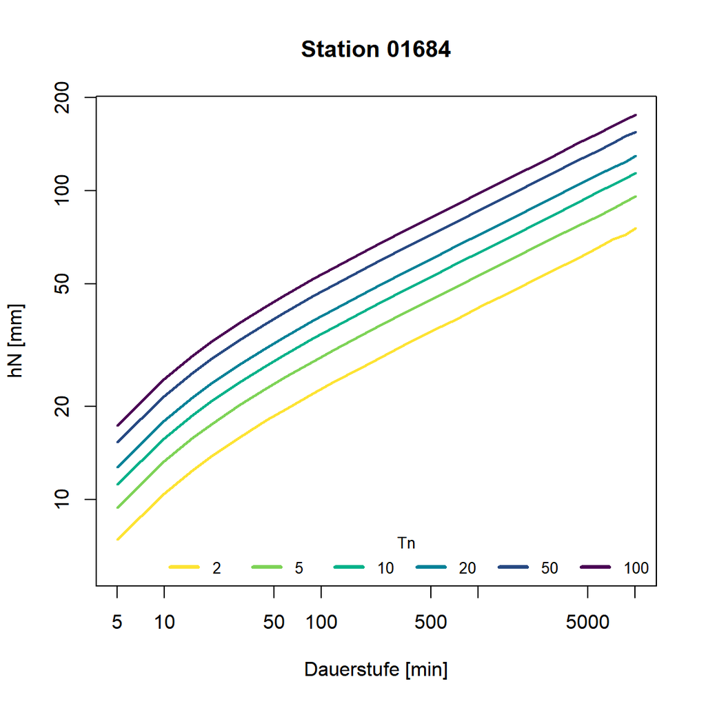

```r
Tn_Farbe <- hcl.colors(6, palette = "viridis") |> rev()

plot(dur, H_quas["2", ], type = "l", lwd = 2, lty = 1, log = "xy", col = Tn_Farbe[1],
     ylab = "hN [mm]", ylim = range(H_quas), xlab = "Dauerstufe [min]",
     main = "Station 01684")

lines(dur, H_quas["5",],  lwd = 2, col = Tn_Farbe[2])
lines(dur, H_quas["10",], lwd = 2, col = Tn_Farbe[3])
lines(dur, H_quas["20",], lwd = 2, col = Tn_Farbe[4])
lines(dur, H_quas["50",], lwd = 2, col = Tn_Farbe[5])
lines(dur, H_quas["100",],lwd = 2, col = Tn_Farbe[6])

legend("bottomright", legend = c(2, 5, 10, 20, 50, 100), lty = 1, lwd = 3, col = Tn_Farbe,
       cex = 0.8, title = "Tn", horiz = TRUE, bty = "n")
```

Im folgenden Beispiel wird die 100-jährliche Niederschlagshöhe auf Basis der lokalen Extremwertstatistik über alle Dauerstufen hinweg visualisiert (rot). Der Mittelwert sowie das Konfidenzintervall der *nBoots* Realisierungen werden ebenfalls im Vergleich dargestellt (blau).

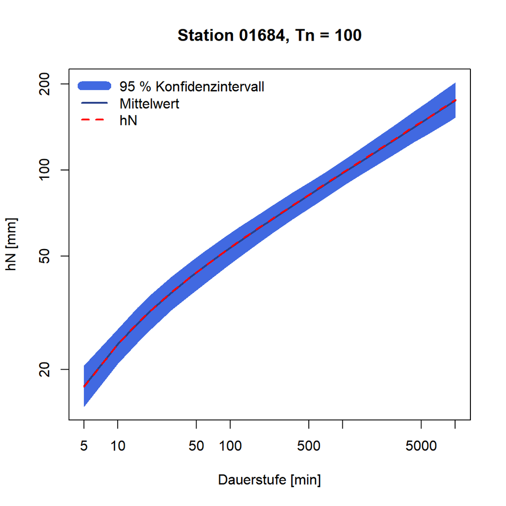

```r
plot(dur, H_quas["100", ], type = "l", lwd = 2, lty = 2, log = "xy",
     ylim = range(HN_KI$`97.5%`["100", ], HN_KI$`2.5%`["100", ]), col = "red",
     ylab = "hN [mm]", xlab = "Dauerstufe [min]", main = "Station 01684, Tn = 100")

polygon(c(dur, rev(dur)),
        c(HN_KI$`2.5%`["100", ], rev(HN_KI$`97.5%`["100", ])),
        col = "royalblue", border = NA)

lines(dur, HN_KI$Mittelwert["100",], type = "l", col = "royalblue4", lwd = 2)

lines(dur, H_quas["100",], type = "l", col = "red", lwd = 2, lty = 2)

legend("topleft",
       c("95 % Konfidenzintervall", "Mittelwert", "hN"),
       col = c("royalblue", "royalblue4", "red"),
       lty = c(1, 1, 2),
       lwd = c(10, 2, 2),
       bty = "n")
```

Das nachfolgende Beispiel zeigt drei Möglichkeiten der Visualisierung von berechneten relativen Unsicherheiten *(Ko-Ku)/K* aus dem *nBoots* Bootstrapping als eine Möglichkeit, die Unsicherheit [%] zu quantifizieren.

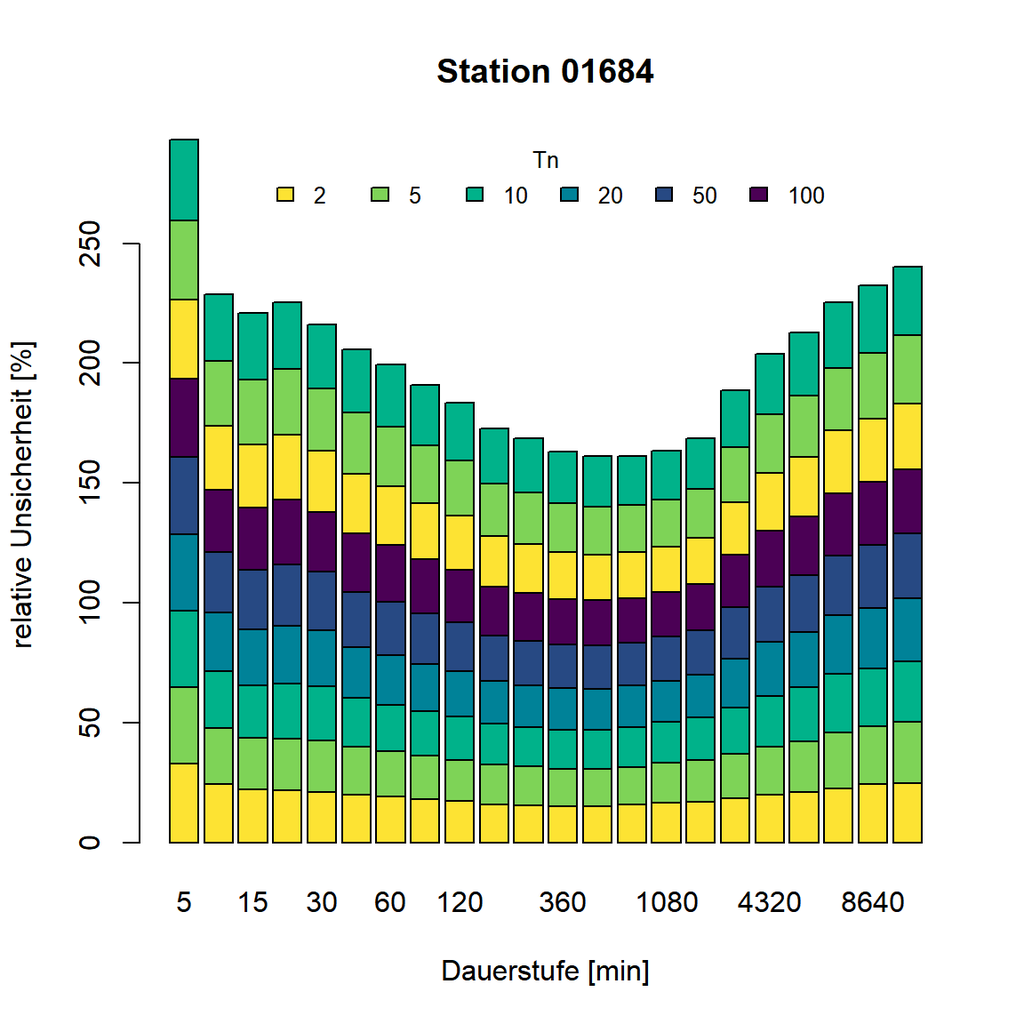

```r
KI_relUC <- round(HN_KI$rel.Unsicherheit, 2)

# Option 1
barplot(as.matrix(KI_relUC), col = Tn_Farbe, ylab = "relative Unsicherheit [%]",  xlab = "Dauerstufe [min]",
        main = "Station 01684")
legend("top", legend = c(2, 5, 10, 20, 50, 100), fill = Tn_Farbe, cex = 0.8,
       title = "Tn", horiz = TRUE, bty = "n")
```

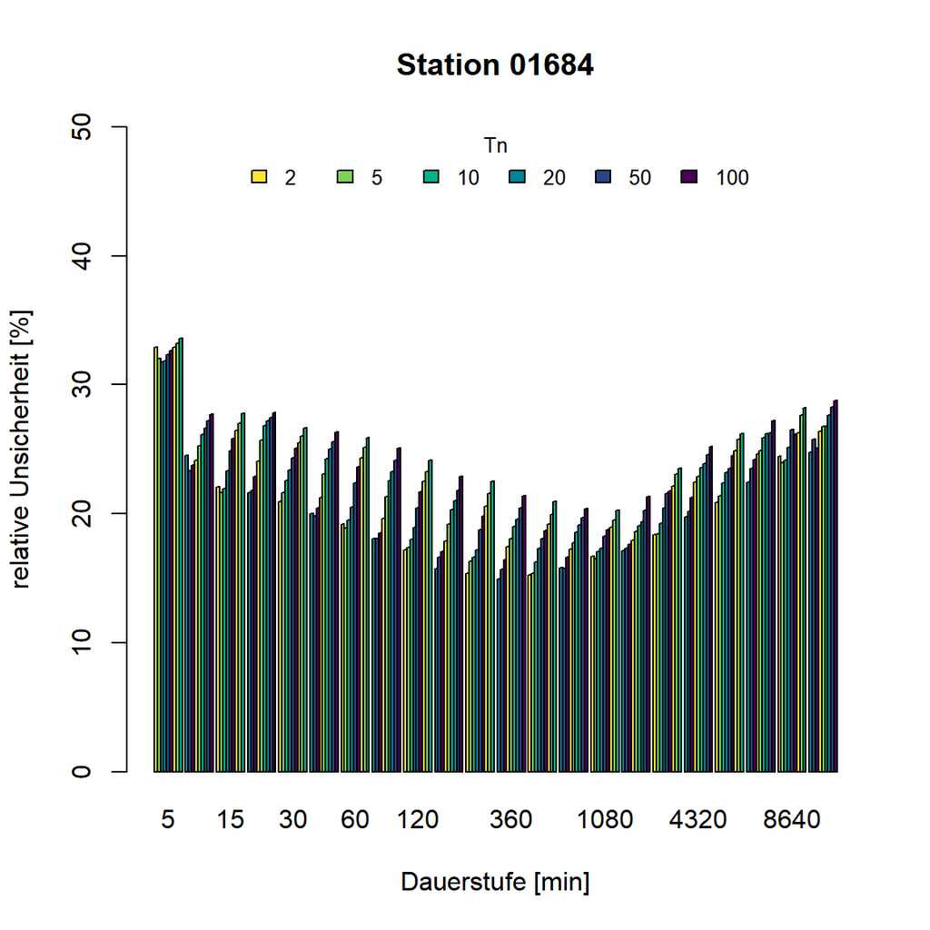

```r
# Option 2
barplot(as.matrix(KI_relUC),col = Tn_Farbe, beside = TRUE, ylim = c(0, 50), ylab = "relative Unsicherheit [%]",
        xlab = "Dauerstufe [min]", main = "Station 01684")
legend("top", legend = c(2, 5, 10, 20, 50, 100), fill = Tn_Farbe, cex = 0.8,
       title = "Tn", horiz = TRUE, bty = "n")
```

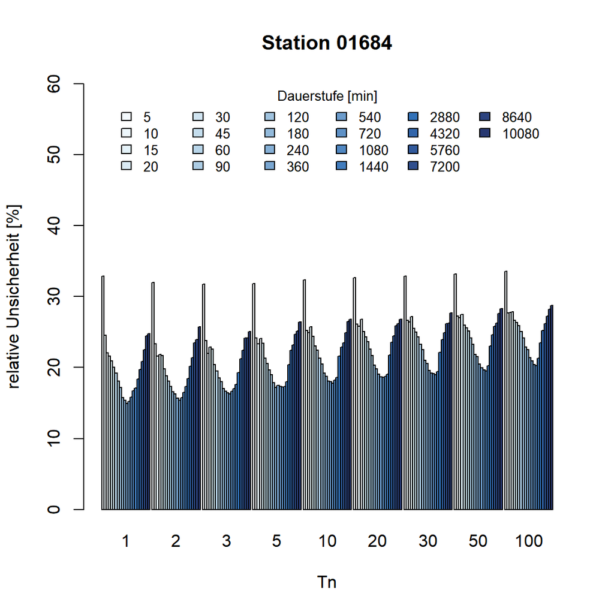

```r
# Option 3
Dauer_Farbe = hcl.colors(dim(KI_relUC)[2], "blues", rev = TRUE)

barplot(as.matrix(t(KI_relUC)), col = Dauer_Farbe, beside = TRUE, ylim = c(0, 60),
        ylab = "relative Unsicherheit [%]", xlab = "Tn", main = "Station 01684")
legend("top", legend = dur, fill = Dauer_Farbe, cex = 0.8, title = "Dauerstufe [min]",
       bty = "n", ncol = 6)
```

### 3.5 Schätzung der Wiederkehrzeiten nach Dauerstufe und Niederschlagshöhe

Mit der geschaffenen Grundlage ist es nun möglich, die Jährlichkeit eines beobachteten Niederschlagsereignisses pro gewählter Dauerstufe zu bestimmen.

Zu diesem Zweck kann die Funktion *Tn_Schaetzung()* verwendet werden. Als Argumente gehen die geschätzten Parameter der Extremwertverteilung *N_pars*, die beobachtete Niederschlagsmenge *hN* in mm sowie die betrachtete Dauerstufe *Dauern* ein. Zudem ist anzugeben, ob Parameter für die Gumbel- oder GEV-Verteilung verwendet wurden.

Während eines Starkregenereignisses am 18.07.2010 wurden an der Station Görlitz eine Niederschlagshöhe von 58.6 mm innerhalb von 6 Stunden gemessen. Basierend auf den geschätzten Parametern beträgt die bestimmte Wiederkehrzeit somit:

```r
Tn_Ereignis <- Tn_Schaetzung(N_pars, hN = 58.6, Dauern = 360, methGEV = "GEV")
Tn_Ereignis
```

```
#>     hN   D Tn
#> 1 58.6 360 26
```

Die Funktion *Tn_Schaetzung()* gibt einen Dataframe mit der beobachteten Regenhöhe hN (mm), der Dauerstufe D (min) und der geschätzten Wiederkehrzeit Tn (a) zurück.

## 4. Vergleiche zwischen lokaler Extremwertstatistik und KOSTRA-DWD-2020

Für einen bestimmten Ort ist es auch möglich, die örtlich geschätzte Statistik mit den Bemessungsniederschlägshöhen nach KOSTRA-DWD-2020 zu vergleichen. In den folgenden Beispielen wird gezeigt, wie die erforderlichen Informationen aus dem Datensatz KOSTRA-DWD-2020 extrahiert und mit den lokal berechneten Informationen verglichen werden können.

Die Funktion *Kostra2020_hN_Schaetzung()* benötigt hierfür definierte Standortkoordinaten, Dauerstufen und Wiederkehrzeiten, um die entsprechende Bemessungsniederschlagshöhe (*hN*) sowie den Unsicherheitsbereich (wenn Argument *Unsicherheit = TRUE*) aus dem Datensatz zu extrahieren.

```r
station <- data.frame(Stations_id = 01684, geoBreite = 51.1621, geoLaenge = 14.9506)

H_quas_Kostra <- Kostra2020_hN_Schaetzung(Standorte = station,
                                          Dauern = dur,
                                          Tn = tn,
                                          Temp_Pfad = "./",
                                          Unsicherheit = TRUE)

# Umformatierung der Regenhöhen, damit diese strukturell dem Objekt H_quas entsprechen
Hn_Kostra <- H_quas_Kostra$Kostra_HN
Hn_Kostra <- matrix(unlist(Hn_Kostra[1, -(1:3)]), nrow = length(tn), byrow = FALSE)
Hn_Kostra <- as.data.frame(Hn_Kostra)
rownames(Hn_Kostra) <- tn
colnames(Hn_Kostra) <- dur
Hn_Kostra
```

```
#>        5   10   15   20   30   45   60   90  120  180  240  360  540  720  1080  1440  2880  4320  5760  7200  8640 10080
#> 1    6.3  8.5  9.9 11.0 12.5 14.1 15.4 17.3 18.7 20.9 22.6 25.2 28.1 30.3  33.8  36.4  43.8  48.7  52.6  55.7  58.5  60.9
#> 2    8.0 10.8 12.6 13.9 15.8 17.9 19.5 21.9 23.7 26.5 28.6 31.9 35.6 38.4  42.8  46.2  55.5  61.7  66.6  70.6  74.1  77.2
#> 3    9.0 12.2 14.2 15.7 17.9 20.2 22.0 24.7 26.8 29.9 32.4 36.1 40.2 43.4  48.4  52.2  62.7  69.8  75.3  79.8  83.8  87.2
#> 5   10.4 14.0 16.4 18.1 20.6 23.3 25.4 28.5 30.9 34.5 37.3 41.6 46.3 50.0  55.7  60.1  72.2  80.3  86.7  91.9  96.5 100.5
#> 10  12.3 16.7 19.5 21.5 24.5 27.7 30.2 33.9 36.7 41.0 44.3 49.5 55.1 59.5  66.3  71.5  85.9  95.6 103.1 109.4 114.8 119.5
#> 20  14.4 19.5 22.7 25.0 28.5 32.3 35.1 39.4 42.7 47.8 51.6 57.6 64.2 69.3  77.2  83.3 100.0 111.3 120.1 127.4 133.6 139.2
#> 30  15.7 21.3 24.8 27.3 31.2 35.3 38.4 43.1 46.7 52.2 56.4 62.9 70.1 75.7  84.3  91.0 109.3 121.6 131.2 139.1 146.0 152.0
#> 50  17.4 23.6 27.5 30.4 34.6 39.2 42.6 47.9 51.9 58.0 62.7 69.9 77.9 84.1  93.6 101.0 121.4 135.1 145.7 154.6 162.2 168.9
#> 100 19.9 27.0 31.4 34.7 39.6 44.8 48.7 54.7 59.3 66.3 71.6 79.9 89.0 96.1 107.0 115.5 138.7 154.4 166.6 176.7 185.4 193.1
```

```r
# Umformatierung der Unsicherheiten, damit diese strukturell dem Objekt H_quas entsprechen
UC_Kostra <- H_quas_Kostra$Kostra_UC
UC_Kostra <- matrix(unlist(UC_Kostra[1, -(1:3)]), nrow = length(tn), byrow = FALSE)
UC_Kostra <- as.data.frame(UC_Kostra)
rownames(UC_Kostra) <- tn
colnames(UC_Kostra) <- dur
UC_Kostra
```

```
#>      5 10 15 20 30 45 60 90 120 180 240 360 540 720 1080 1440 2880 4320 5760 7200 8640 10080
#> 1   12 13 15 16 17 17 17 17  17  16  15  14  14  13   13   13   13   14   15   15   16    17
#> 2   12 15 17 18 19 20 20 19  19  18  17  16  15  15   14   14   14   14   15   15   16    16
#> 3   12 15 18 19 20 21 21 20  20  19  18  17  16  16   15   15   14   15   15   16   16    16
#> 5   13 16 19 20 21 22 22 21  21  20  19  18  17  17   16   16   15   15   16   16   16    16
#> 10  13 18 20 21 22 23 23 23  22  21  21  20  19  18   17   17   16   16   16   16   16    17
#> 20  14 18 21 22 23 24 24 24  23  22  22  20  19  19   18   17   16   16   16   17   17    17
#> 30  14 19 21 22 24 24 24 24  24  23  22  21  20  19   18   18   17   17   17   17   17    17
#> 50  15 19 22 23 24 25 25 25  24  23  22  21  20  20   19   18   17   17   17   17   17    17
#> 100 15 20 22 24 25 25 25 25  25  24  23  22  21  20   19   19   18   17   17   17   18    18
```

```r
# Da die KOSTRA-DWD-2020 Unsicherheiten in Prozent angegeben sind, kann die
# obere und untere Konfidenzgrenze wie folgt berechnet werden:
Hn_Kostra_Ku <- Hn_Kostra - round(Hn_Kostra * UC_Kostra / 100, 2)
Hn_Kostra_Ko <- Hn_Kostra + round(Hn_Kostra * UC_Kostra / 100, 2)
```

Das nachfolgende Beispiel zeigt eine Erweiterung der unter 3.4 erzeugten Abbildung zum Vergleich der 100-jährlichen Niederschlagshöhe auf Basis der lokalen Extremwertstatistik (rot) mit dem Mittelwert sowie dem Konfidenzintervall der *nBoots* Realisierungen (blau) im Vergleich zur Bemessungsniederschlagshöhe (schwarz) und dem Unsicherheitsbereich (grau) gem. KOSTRA-DWD-2020.

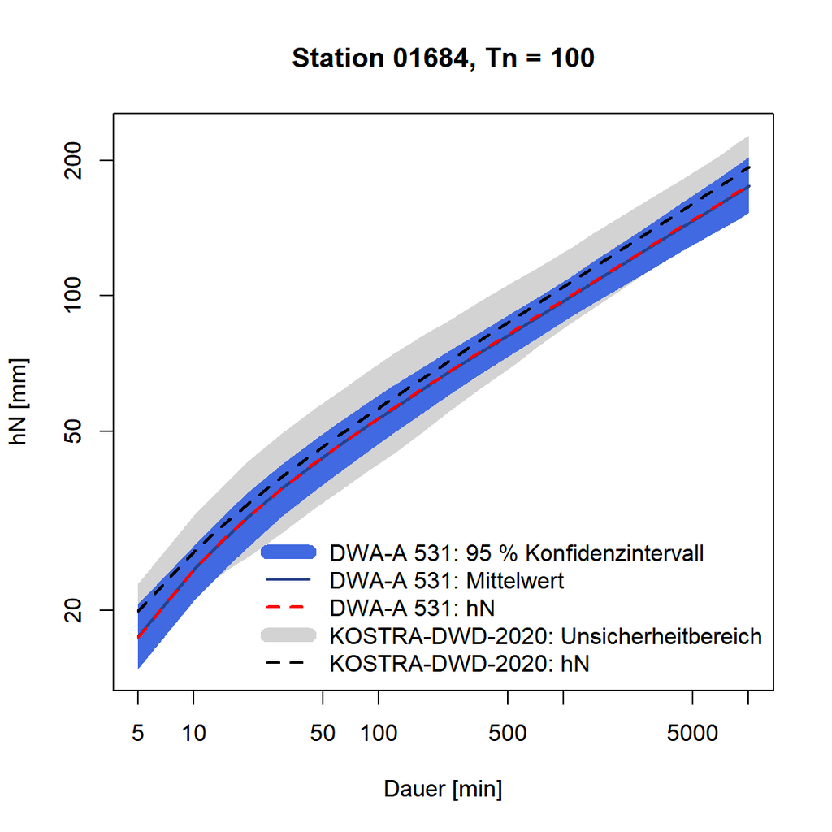

```r
plot(dur, H_quas["100", ],
     type = "l",
     lwd = 2,
     lty = 2,
     log = "xy",
     ylim = range(HN_KI$`97.5%`["100", ], HN_KI$`2.5%`["100", ],
                  Hn_Kostra_Ku["100", ], Hn_Kostra_Ko["100", ]),
     col = "red",
     ylab = "hN [mm]",
     xlab = "Dauer [min]",
     main = "Station 01684, Tn = 100")

polygon(c(dur, rev(dur)), c(Hn_Kostra_Ku["100", ], rev(Hn_Kostra_Ko["100", ])),
        col = "lightgrey",
        border = NA)
polygon(c(dur, rev(dur)), c(HN_KI$`2.5%`["100", ], rev(HN_KI$`97.5%`["100", ])),
        col = "royalblue",
        border = NA)

lines(dur, HN_KI$Mittelwert["100", ], type = "l", col = "royalblue4", lwd = 2)
lines(dur, H_quas["100", ], type = "l", col = "red", lwd = 2, lty = 2)
lines(dur, Hn_Kostra["100", ], type = "l", col = "black", lwd = 2, lty = 2)

legend("bottomright",
       c("DWA-A 531: 95 % Konfidenzintervall",
         "DWA-A 531: Mittelwert",
         "DWA-A 531: hN",
         "KOSTRA-DWD-2020: Unsicherheitbereich",
         "KOSTRA-DWD-2020: hN"),
       col = c("royalblue", "royalblue4", "red", "lightgrey", "black"),
       lty = c(1, 1, 2, 1, 2),
       lwd = c(10, 2, 2, 10, 2),
       bty = "n")
```

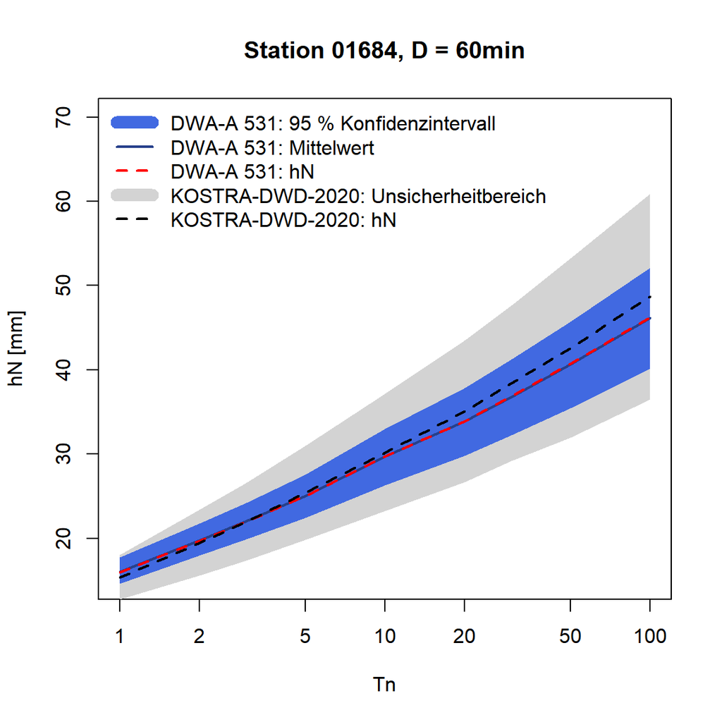

```r
plot(tn, H_quas[, "60"],
     type = "l",
     lwd = 2,
     lty = 2,
     log = "x",
     ylim = range(15, 70),
     col = "red",
     ylab = "hN [mm]",
     xlab = "Tn",
     main = "Station 01684, D = 60min")

polygon(c(tn, rev(tn)), c(Hn_Kostra_Ku[,"60"], rev(Hn_Kostra_Ko[,"60"])),
        col = "lightgrey",
        border = NA)
polygon(c(tn, rev(tn)), c(HN_KI$`2.5%`[,"60"], rev(HN_KI$`97.5%`[,"60"])),
        col = "royalblue",
        border = NA)

lines(tn, HN_KI$Mittelwert[, "60"], type = "l", col = "royalblue4", lwd = 2)
lines(tn, H_quas[, "60"], type = "l", col = "red", lwd = 2, lty = 2)
lines(tn, Hn_Kostra[, "60"], type = "l", col = "black", lwd = 2, lty = 2)

legend("topleft",
       c("DWA-A 531: 95 % Konfidenzintervall",
         "DWA-A 531: Mittelwert",
         "DWA-A 531: hN",
         "KOSTRA-DWD-2020: Unsicherheitbereich",
         "KOSTRA-DWD-2020: hN"),
       col = c("royalblue", "royalblue4", "red", "lightgrey", "black"),
       lty = c(1, 1, 2, 1, 2),
       lwd = c(10, 2, 2, 10, 2),
       bty = "n")
```

Die Funktion *Kostra2020_Parameter()* liest für definierte Standortkoordinaten die entsprechenden Parameter der Extremwertverteilung aus KOSTRA-DWD-2020. Im folgenden Beispiel werden die Parameter für den Standort der Station Görlitz bezogen. Im Anschluss wird die bereits bekannte Funktion *Tn_Schaetzung()* verwendet, um die Wiederkehrzeit der beobachteten Niederschlagsmenge *hN* in der angegebenen Dauerstufe zu schätzen.

```r
kostraParameter <- Kostra2020_Parameter(Standorte = station)

Hn_Tn_Kostra <- Tn_Schaetzung(kostraParameter, hN = 58.6, Dauern = 360, methGEV = "GEV")
Hn_Tn_Kostra
```

```
#>     hN   D Tn
#> 1 58.6 360 21
```

# Fazit

Diese Vignette zeigt, wie mit dem Paket `Nextreme` eine lokale Extremwertanalyse gemäß Arbeitsblatt DWA-A 531 durchgeführt werden kann. Am Beispiel der Station Görlitz wurde der gesamte Analyseprozess detailliert dargestellt. Das Paket bietet damit ein leistungsfähiges Werkzeug für die praxisnahe Starkregenanalyse.

## Weiterführende Informationen

Weitere Informationen und Hilfestellungen zu den Funktionen finden Sie in der Paketdokumentation oder mit dem Befehl `?function` in R. Bei Fragen oder Feedback wenden Sie sich gerne an den Maintainer des Paketes.